# Forecasting MBTA Ferry Ridership

Andrew Disher

2024-01-19

**This document records my efforts to model MBTA ferry ridership data with various time series models. The data, provided by the Massachusetts Bay Transport Authority, is available at their [open data portal](https://mbta-massdot.opendata.arcgis.com/). It is located within the section titled Ridership, under Data By Category, and can be found [here](https://mbta-massdot.opendata.arcgis.com/search?tags=ridership).**

## Goals of this Project

1. Aggregate the data according to day, since it is stored as boat trips with passenger counts.
2. Identify any outliers or missing data, and perform data imputation if necessary.
3. Perform time series cross validation during model selection.
4. Identify suitablee models for forecasting. Modeling methods considered include ARIMA, ETS, and Dynamic Harmonic Regression.
5. Produce forecasts to compare models’ performance.
6. Produce a combination forecast, averaging the point forecasts of each model and creating a combined prediction interval. This is a form of *ensemble forecasting*.

## 1 Import necessary packages and functions

```r
box::use(
  dplyr[`%>%`, arrange, case_when, group_by, filter, mutate, pull, row_number, select,
        summarize, ungroup],
  fable[...],
  fabletools[...],
  feasts[ACF, guerrero, PACF, STL],
  generics[augment, glance],
  ggplot2[...],
  gridExtra[...],
  gt[cell_fill, cells_body, gt, tab_footnote, tab_header, tab_style],
  imputeTS[ggplot_na_distribution, ggplot_na_imputations, na_interpolation],
  lubridate[day, hour, month, year],
  MASS[fitdistr],
  tidyr[everything, pivot_longer, pivot_wider],
  tsibble[...],
)
```

```r
box::use(
  functions/plotting[time_series]
)
```

### 1.1 Notes on Packages Used

We have decided to use the `box` package to handle our package imports, since it makes more explicit what functions we will be using in our analyses. Package imports with […] declared simply imply that we’ll be importing all functions from those packages, similar to `library()` calls, which is done only for some packages since we use so many of their functions in this document.

Box also allows us to import our custom functions, written in files stores within this project, as well. This is useful because we can also create documentation for these functions with `roxygen2` style decorators. So, if you would like to examine the code within the *forecasting.R* file, you can call `box::help(module_name$function_name)` and be provided insights from help pages on how to use such functions in the code. This functionality is very similar to a package’s help page functionality, with the added benefit of not creating a package.

Data manipulation will be performed mainly using packages like `dplyr`, but we also import `lubridate` for easier ways to work with dates in R, `tidyr` to convert data frames from long format to wide format (and vice versa). `ggplot2` is used as our primary graphing library, along with the `grid` package to help arrange plots side by side. `tsibble` provides a unique tibble format for our time series data be stored in, which has special properties that make it more convenient to work with compared to data frames and traditional tibbles.

Our tools for estimating and fitting time series models come from a variety of packages, including `fable`, `fabletools`, and `feasts`. These provide ways to work with and fit models in a **tidymodels** style, which makes use of pipes in our code for cleaner and more readable code.

## 2 Data Cleaning

### 2.1 Examing the Data Set Structure

First, we’ll import the data and see what it looks like.

```r
ferry_ridership <- read.csv("data/ferry_ridership.csv")

str(ferry_ridership, vec.len = 2)
```

```
## 'data.frame':    212860 obs. of  21 variables:
##  $ service_date        : chr  "2018/11/13 05:00:00+00" "2018/11/13 05:00:00+00" ...
##  $ route_id            : chr  "F1" "F1" ...
##  $ route_name          : chr  "F1-Hingham" "F1-Hingham" ...
##  $ trip_freq           : chr  "M-F" "M-F" ...
##  $ trip_freq_adj       : chr  "All" "All" ...
##  $ sub_route           : chr  "F1-Hingham-Boston" "F1-Boston-Hingham" ...
##  $ trip_id             : chr  "08:45-F1-HNG-RWF" "16:30-F1-RWF-HNG" ...
##  $ stop_id             : chr  "08:45-F1-HNG-RWF" "16:30-F1-RWF-HNG" ...
##  $ departure_terminal  : chr  "Hingham" "Rowes Wharf" ...
##  $ mbta_sched_departure: chr  "2018/11/13 13:45:00+00" "2018/11/13 21:30:00+00" ...
##  $ actual_departure    : chr  "2018-11-13 08:46:00" "2018-11-13 16:31:00" ...
##  $ pax_on              : int  153 183 5 215 1 ...
##  $ pax_load            : int  153 183 5 215 1 ...
##  $ pax_off             : chr  "-153" "-183" ...
##  $ mbta_sched_arrival  : chr  "2018/11/13 14:20:00+00" "2018/11/13 22:05:00+00" ...
##  $ actual_arrival      : chr  "2018-11-13 09:19:00" "2018-11-13 17:02:00" ...
##  $ arrival_terminal    : chr  "Rowes Wharf" "Hingham" ...
##  $ vessel_time_slot    : chr  "Vessel B" "Vessel B" ...
##  $ trip_endpoint       : chr  "Trip Endpoint" "Trip Endpoint" ...
##  $ travel_direction    : chr  "To Boston" "From Boston" ...
##  $ ObjectId            : int  1 2 3 4 5 ...
```

There is a lot of information about thinks such as service date, scheduled departures, and about the trip itself, like its direction and destination.

Many of the variables in the original data set are not really needed, so I will remove the ones that wont be necessary. We’ll only keep the variables for `actual_departure` time and `pax_on`, which just tells us how many passengers boarded the vessel.

```r
ferry_ridership <- ferry_ridership %>%
  select(c(actual_departure, pax_on, ))

str(ferry_ridership, vec.len = 2)
```

```
## 'data.frame':    212860 obs. of  2 variables:
##  $ actual_departure: chr  "2018-11-13 08:46:00" "2018-11-13 16:31:00" ...
##  $ pax_on          : int  153 183 5 215 1 ...
```

`actual_departure` is a character vector, which will help us create numerous other variables for day, day of week, month, and year, as well as an R Date vector.

```r
ferry_ridership <- ferry_ridership %>%
  mutate(actual_departure = as.POSIXct(actual_departure),
         year = year(actual_departure),
         month = month(actual_departure),
         day = day(actual_departure),
         hour = hour(actual_departure)) %>%
  mutate(new_date = paste0(year, "-", month, "-", day) %>%
           as.Date(format = "%Y-%m-%d"),
         DOW = weekdays(new_date)) %>%
  filter(!(DOW %in% c("Saturday", "Sunday")))

ferry_ridership %>%
  head()
```

```
##      actual_departure pax_on year month day hour   new_date     DOW
## 1 2018-11-13 08:46:00    153 2018    11  13    8 2018-11-13 Tuesday
## 2 2018-11-13 16:31:00    183 2018    11  13   16 2018-11-13 Tuesday
## 3 2018-11-13 17:07:00      5 2018    11  13   17 2018-11-13 Tuesday
## 4 2018-11-13 18:01:00    215 2018    11  13   18 2018-11-13 Tuesday
## 5 2018-11-13 18:41:00      1 2018    11  13   18 2018-11-13 Tuesday
## 6 2018-11-13 19:31:00     67 2018    11  13   19 2018-11-13 Tuesday
```

Very nice. A good idea would be to check the range of dates that we are working with.

```r
ferry_ridership$new_date %>%
  range(na.rm = TRUE)
```

```
## [1] "2018-11-01" "2023-08-31"
```

Our data spans from November of 2018 to August of of 2023. This is good, since we’ll have plenty of data to help establish various seasonal cycles that will certainly be present in such data as this.

You’ll notice we specified the argument `na.rm = TRUE`; this is because there are NAs in our data, which prevents the `range` function from doing its job. Now that we know what our date range is, we’ll proceed to examine these missing values.

### 2.2 Missing Values

The variable we are interested in is `pax_on`. Again, this variable tells us how many passengers boarded a vessel on a given trip. We are interested in creating time series models for daily data, so we will end up aggregating it.

Before we do so, we should check to see if `pax_on` contains missing values in case they might present us with issues in aggregation.

```r
ferry_ridership[is.na(ferry_ridership$pax_on),] %>%
  select(new_date) %>%
  unique()
```

```
##          new_date
## 113585 2022-02-03
## 115480 2022-05-25
## 116014 2022-06-30
## 120183 2023-02-02
## 127746 2022-04-20
## 156445 2022-01-17
## 158159 2022-02-16
## 173582 2022-11-24
## 179509 2023-03-14
## 184370 2023-06-09
```

It turns out we have a number of dates with missing values. Some dates have multiple trips that have missing values, while some have missing values for `pax_on` for ALL trips that were scheduled for that day.

This is going to pose an issue with our data aggregation, especially since we want to use our boardings variable to create a new variable for average number of boardings per day.

So, what we’ll do is aggregate our data by day, and then examine the specific days where all of the trips for that day were NAs.

```r
daily_ridership <- ferry_ridership %>%
  group_by(year, month, day, new_date) %>%
  summarize(boardings = sum(pax_on, na.rm = TRUE),
            avg_boardings = mean(pax_on, na.rm = TRUE)) %>%
  ungroup()

daily_ridership[is.na(daily_ridership$avg_boardings), ] %>%
  select(new_date)
```

```
## # A tibble: 3 × 1
##   new_date
##   <date>
## 1 2022-01-17
## 2 2022-11-24
## 3 2023-03-14
```

We have three dates of interest. After some research, I discovered that on January 17th, 2022 the east of coast Massachusetts experienced some high velocity winds (50-70 mph). These winds, along with some heavy rain suspended ferry service due to unsafe conditions. On March 14th, 2023 there was a Nor’Easter with heavy rains and some coastal flooding, which must also have been responsible for a suspension of service.

I was not able to identify the reason for missing values for November 24th, 2022, however the fact remains that we have missing values. For these reasons, we are going to impute some values for these dates in our time series using a data interpolation technique included in the `imputeTS` package.

In addition, I was able to identify one last Date, December 17th, 2020, where a severe Nor’Easter again hit the east coast of the entire Northeast United States. I found many articles explaining that the MBTA again suspended ferry service on this date. Boston ended up getting a foot of snow, which was more than the entire previous Winter combined. However, zeros where logged, instead of NAs, which explains why we couldn’t find it through our data set search before.

### 2.3 Covid-19 Pandemic

Before we start interpolating data to impute values for the dates mentioned before, I think it is worth it to first acknowledge a certain reality in our data.

Our data contains the period when the Covid-19 pandemic happened. I know for a fact that the MBTA suspended ferry service for a time when the pandemic began. This is reflected in our data if we look at the rows below.

```r
daily_ridership[352, "new_date"]
```

```
## # A tibble: 1 × 1
##   new_date
##   <date>
## 1 2020-03-16
```

```r
daily_ridership[353, "new_date"]
```

```
## # A tibble: 1 × 1
##   new_date
##   <date>
## 1 2020-06-22
```

This is a large gap in data that no amount of data interpolation can solve, so unfortunately we will have remove the observations in the data set that occur before June 22nd, 2020. This is likely a good thing anyways, since the ridership trends in the first few months of the pandemic would have undoubtedly been far different than typical ridership trends.

```r
post_covid_daily_ridership <- daily_ridership %>%
  filter(new_date >= as.Date("2020-06-22")) %>%
  mutate(day_index = row_number()) %>%
  as_tsibble(index = day_index)

post_covid_daily_ridership$new_date %>%
  range()
```

```
## [1] "2020-06-22" "2023-08-31"
```

You’ll see we also created a new variable, called `day_index.` This will help with our data modeling, which will become more obvious later.

### 2.4 Data Imputation

We’ll begin by creating a simple vector of dates that we’ll dub *problem dates* and use it to help us impute our data.

```r
problem_dates <- as.Date(c("2020-12-17", "2022-01-17", "2022-11-24", "2023-03-14"))
```

As a reminder, this is what our data looks like.

```r
post_covid_daily_ridership %>%
  filter(new_date %in% problem_dates)
```

```
## # A tsibble: 4 x 7 [1]
##    year month   day new_date   boardings avg_boardings day_index
##   <dbl> <dbl> <int> <date>         <int>         <dbl>     <int>
## 1  2020    12    17 2020-12-17         0             0       127
## 2  2022     1    17 2022-01-17         0           NaN       403
## 3  2022    11    24 2022-11-24         0           NaN       626
## 4  2023     3    14 2023-03-14         0           NaN       703
```

The values of concern are in the `avg_boardings` column. We’ll convert these values to NAs so `imputeTS` functions can identify which values we’d like to treat.

```r
post_covid_daily_ridership <- post_covid_daily_ridership %>%
  mutate(avg_boardings = case_when(is.nan(avg_boardings) ~ NA,
                                   new_date == as.Date("2020-12-17") ~ NA,
                                   TRUE ~ avg_boardings))
```

Below, we visualize the sections of our time series that we’d like to impute values for.

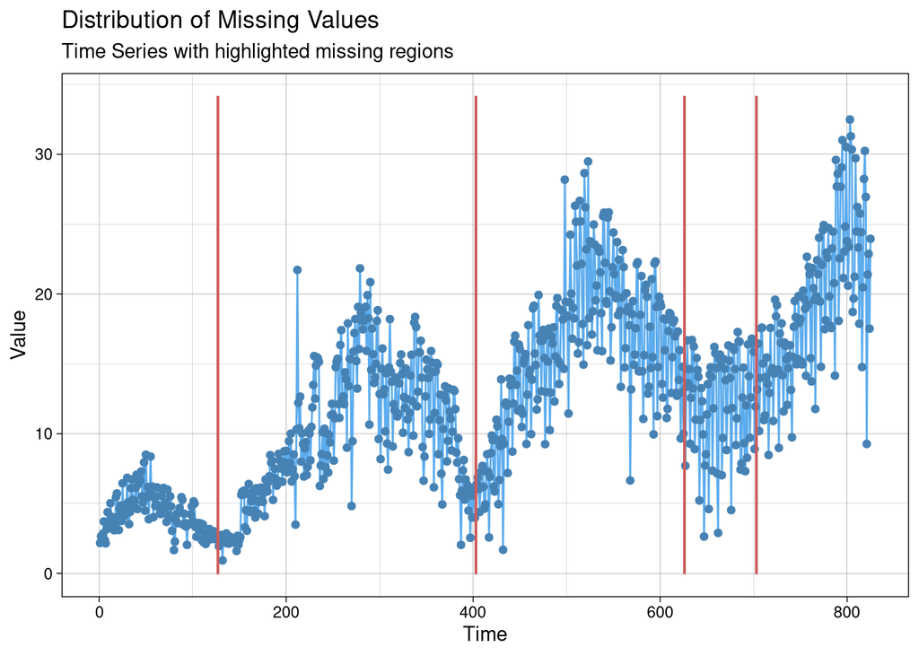

```r
ggplot_na_distribution(post_covid_daily_ridership$avg_boardings)
```

We’ll use the `na_interpolation()` function from `imputeTS` to impute values using a spline interpolation technique. There are many techniques available in the package, but for our data they produced almost identical results when I tested them.

```r
interp <- na_interpolation(post_covid_daily_ridership$avg_boardings, option = "spline", method = "natural")
```

To visualize the results we can run the following code.

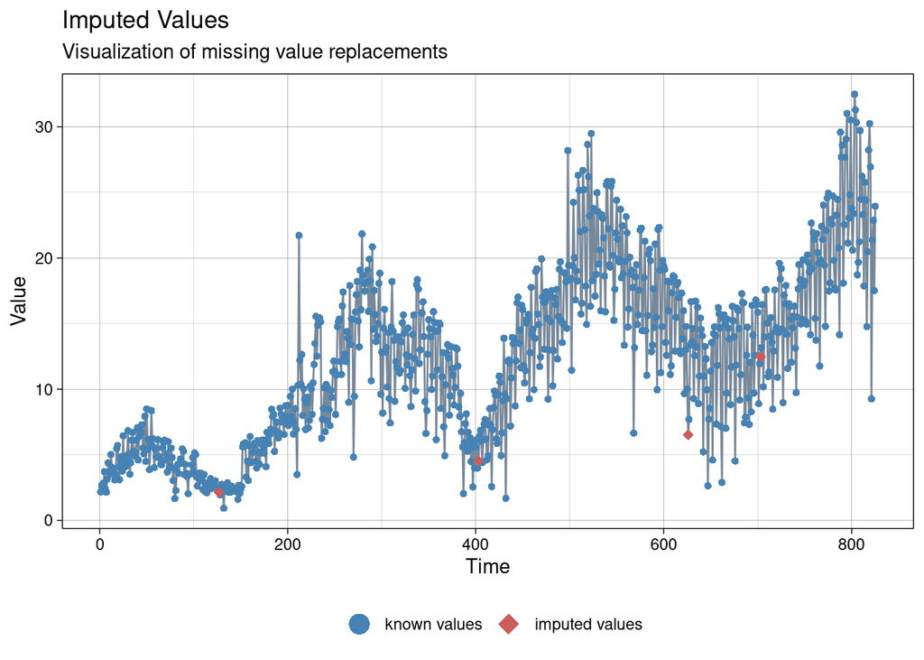

```r
ggplot_na_imputations(post_covid_daily_ridership$avg_boardings, interp)
```

The results look acceptable to me, so we’ll go ahead and replace our data with the interpolated data.

```r
post_covid_daily_ridership <- post_covid_daily_ridership %>%
  mutate(avg_boardings = interp)
```

## 3 Data Visualization

### 3.1 Daily Average Ferry Boardings

Now that we have cleaned our data, we can begin to examine some of the trends in it. First, we’ll plot the time series again for average boardings and then check its ditribution. We create these plots using functions that I have defined, which can be found in the `functions/plotting` directory of the github repository this code is in.

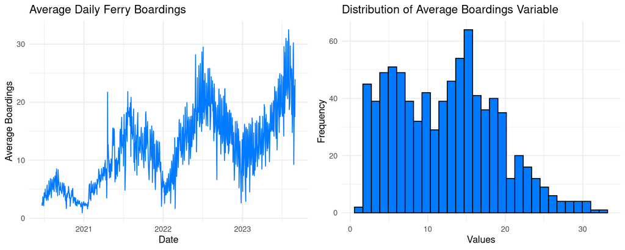

```r
grid.arrange(
  time_series$plotTS(data = post_covid_daily_ridership,
                     date_var = "new_date",
                     y_var = "avg_boardings",
                     y = "Average Boardings",
                     title = "Average Daily Ferry Boardings"),
  time_series$plotHist(data_vec = post_covid_daily_ridership$avg_boardings,
                      title = "Distribution of Average Boardings Variable"),
  ncol = 2
)
```

We can see from the histogram that the distribution is a bit right-skewed, since we do tend to see a decent number of extreme values in our series. This could be due to holidays, where public transportation might experience higher passengers volumes. While we do discuss seasonality in our models later, we will not consider seasonality in yearly holidays.

Also, we can see that our time series exhibits heteroschedasticity; it has non-constant variance, which will impact our models in a large way. Therefore, we should explore the use of transformations, namely Box-Cox transformations, for our dependent variable.

Before doing so, let’s take a look at the autocorrelation function (ACF) and partial autocorrelation function (PACF) for our time series.

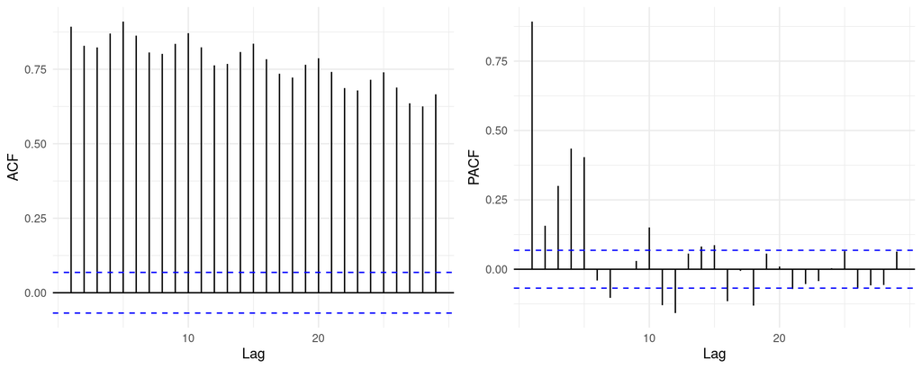

```r
grid.arrange(
  post_covid_daily_ridership %>%
    ACF(boardings) %>%
    autoplot() +
    theme_minimal() +
    labs(x = "Lag",
         y = "ACF"),
  post_covid_daily_ridership %>%
    PACF(boardings) %>%
    autoplot() +
    theme_minimal() +
    labs(x = "Lag",
         y = "PACF"),
  ncol = 2)
```

These graphics are incredibly useful when working with time series data, and will prove to be absolutely necessary when creating the ARIMA model we mentioned earlier.

The ACF is showing us the correlations between values of our series between previous values in the series, thus *auto*-correlation. There is significant autocorrelations for many lags in our data, indicating that the previous values in the series will be useful for predicting future values.

The PACF is similar to the ACF, except that it removes removes any *partial* correlations that are introduced with lags between the two lags of interest. In other words, when we would like to see if the value at time *t* in our series is correlated with the value at time *t-8*, partial correlations existing between lag 8 and lag 5, for example, tend to inflate the correlation between lag 8 and our current value. The PACF removes these confounding correlations, and gives us an more *pure* correlation between lag 8 and our current value. We also see significant correlation here.

In both cases, we see some obvious seasonality. It’s probably easier to see in the ACF. There are many repeated jumps in the hight of the lags, every 5 lags. This makes sense because our data is not just weekly data, but it is data for the weekdays. Therefore, we would expect a periodicity of 5. The chart below makes this idea more concrete.

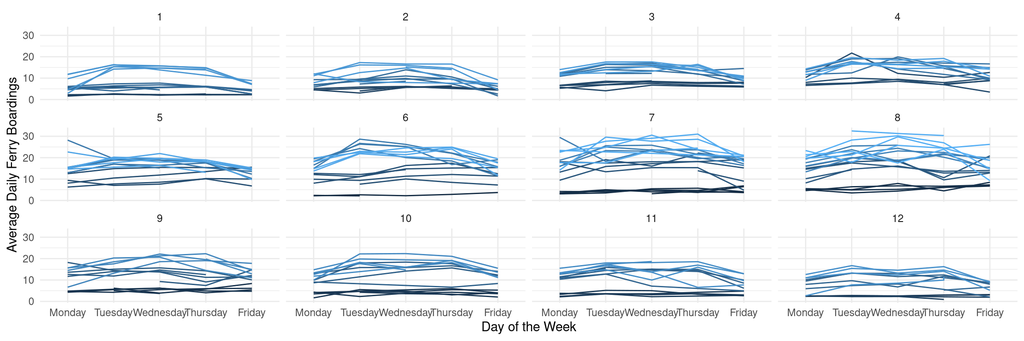

```r
level_order <- c("Monday", "Tuesday", "Wednesday", "Thursday", "Friday")

post_covid_daily_ridership %>%
  mutate(DOW = weekdays(new_date),
         group_var = rep(1:165, each = 5)) %>%
  ggplot(mapping = aes(x = factor(DOW, level = level_order),
                       y = avg_boardings,
                       group = group_var,
                       color = group_var)) +
  geom_line() +
  theme_minimal() +
  theme(legend.position = "none") +
  facet_wrap(vars(month)) +
  labs(x = "Day of the Week",
       y = "Average Daily Ferry Boardings")
```

### 3.2 Box-Cox Transformations

In order to reduce the adverse effects that non-constant variance will have on our models, we can transform our variable, average boardings, such that it exhibits more homoschedasticity.

We can first run this R code to learn what the most optimal transformation will be for this hyperparameter.

```r
lambda <- post_covid_daily_ridership %>%
  features(avg_boardings, features = guerrero) %>%
  pull(lambda_guerrero)

lambda
```

```
## [1] 0.2731198
```

This lambda value is estimated using the Guerrero estimation method, rather than log-likelihood. Guerrero’s method has proven to be more effective when dealing with time series data, which makes it more suitable here than with linear regression, for example.

This lambda value will be used in a Box-Cox transformation, which you can read more about it [here](https://en.wikipedia.org/wiki/Power_transform#Box%E2%80%93Cox_transformation), if you are interested.

We’ll apply the transformation below.

```r
post_covid_daily_ridership <- post_covid_daily_ridership %>%
  mutate(avg_boardings_trans = box_cox(avg_boardings + 1, lambda))
```

Now, we can view the results of the transformation by plotting in the same way we did for the original series.

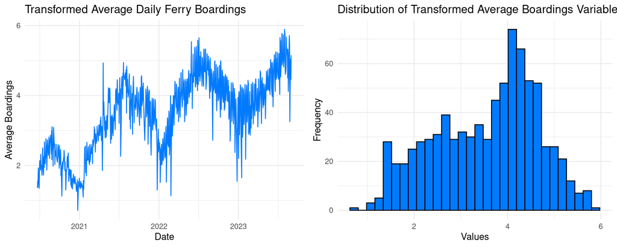

```r
grid.arrange(
  time_series$plotTS(data = post_covid_daily_ridership,
                     date_var = "new_date",
                     y_var = "avg_boardings_trans",
                     y = "Average Boardings",
                     title = "Transformed Average Daily Ferry Boardings"),
  time_series$plotHist(data_vec = post_covid_daily_ridership$avg_boardings_trans,
                       title = "Distribution of Transformed Average Boardings Variable"),
  ncol = 2
)
```

You’ll notice that the variance seems much more constant throughout the series, which means that our ARIMA model will perform better once we start trying to model it. This is because ARIMA models depend on a certain set of assumptions, which include stationarity in the mean and stationarity in the variance.

You’ll also notice that the unit scale of the boardings variable has now changed drastically, but that is OK. Once we obtain forecasts for a model, we can back-transform the variable using the inverse transform function to obtain forecasts on the original scale.

We can also examine the autocorrelation functions mentioned earlier and observe that the underlying correlation structure remains largely intact compared to what we had before. The same weekly seasonality exists.

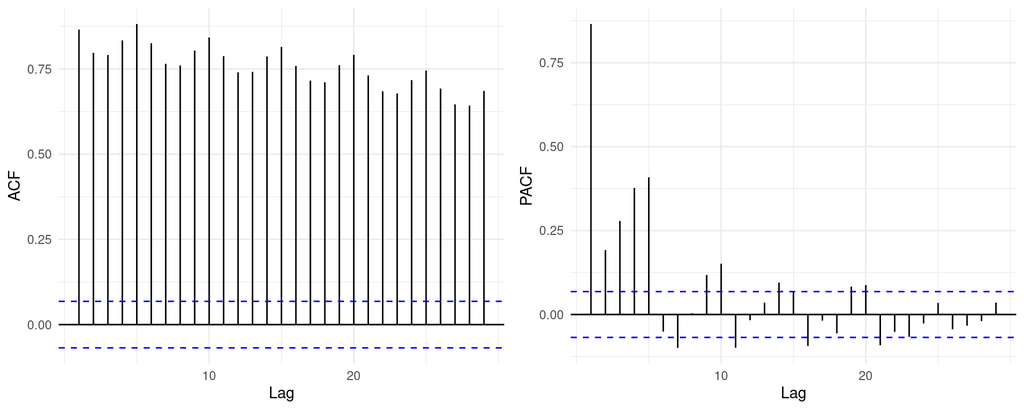

```r
grid.arrange(
  post_covid_daily_ridership %>%
    ACF(avg_boardings_trans) %>%
    autoplot() +
    theme_minimal() +
    labs(x = "Lag",
         y = "ACF"),
  post_covid_daily_ridership %>%
    PACF(avg_boardings_trans) %>%
    autoplot() +
    theme_minimal() +
    labs(x = "Lag",
         y = "PACF"),
  ncol = 2
)
```

## 4 ARIMA Modeling

### 4.1 Small Discussion of ARIMA

Now that we have a suitable data set, we can begin modeling. The first model that we will try is ARIMA. ARIMA stands for autoregressive integrated moving average, and this model has been one of the go tos for many time series forecasters. It can be extended to accommodate some different types of seasonality, but not all.

To specify ARIMA(*p*, *d*, *q*) models, you must choose choose the values for the *p*, *d*, and *q* parameters based off of what is observed in the ACF and PACF plots we have been looking at. You can read more about specifying and iteratively re-fitting models using these plots [here](https://otexts.com/fpp3/arima.html). We will not go too in depth discussing how to fit an ARIMA model here, since it is a lengthy process.

### 4.2 Comparing AICc and BIC of Models

After applying sufficient differencing and seasonal differencing transformations to the data, I was able to identify a suite of potential models, some simple and some more complex.

```r
arima_models <- post_covid_daily_ridership %>%
  model(
    seasonal_diff = ARIMA(box_cox(avg_boardings, lambda) ~ pdq(0, 0, 0) + PDQ(0, 1, 0, period = 5)),
    arima_000_011 = ARIMA(box_cox(avg_boardings, lambda) ~ pdq(0, 0, 0) + PDQ(0, 1, 1, period = 5)),
    arima_100_011 = ARIMA(box_cox(avg_boardings, lambda) ~ pdq(1, 0, 0) + PDQ(0, 1, 1, period = 5)),
    nonseasonal_diff = ARIMA(box_cox(avg_boardings, lambda) ~ pdq(0, 1, 0) + PDQ(0, 0, 0, period = 5)),
    double_diff = ARIMA(box_cox(avg_boardings, lambda) ~ pdq(0, 1, 0) + PDQ(0, 1, 0, period = 5)),
    arima_010_011 = ARIMA(box_cox(avg_boardings, lambda) ~ pdq(0, 1, 0) + PDQ(0, 1, 1, period = 5)),
    arima_011_011 = ARIMA(box_cox(avg_boardings, lambda) ~ pdq(0, 1, 1) + PDQ(0, 1, 1, period = 5)),
    arima_012_011 = ARIMA(box_cox(avg_boardings, lambda) ~ pdq(0, 1, 2) + PDQ(0, 1, 1, period = 5)),
    arima_111_011 = ARIMA(box_cox(avg_boardings, lambda) ~ pdq(1, 1, 1) + PDQ(0, 1, 1, period = 5)),
    auto_fit = ARIMA(box_cox(avg_boardings, lambda)),
  )
```

We can see the model specs here,

```r
arima_models %>%
  pivot_longer(everything(),
               names_to = "Model",
               values_to = "Orders")
```

```
## # A mable: 10 x 2
## # Key:     Model [10]
##    Model                                       Orders
##    <chr>                                      <model>
##  1 seasonal_diff             <ARIMA(0,0,0)(0,1,0)[5]>
##  2 arima_000_011    <ARIMA(0,0,0)(0,1,1)[5] w/ drift>
##  3 arima_100_011    <ARIMA(1,0,0)(0,1,1)[5] w/ drift>
##  4 nonseasonal_diff                    <ARIMA(0,1,0)>
##  5 double_diff               <ARIMA(0,1,0)(0,1,0)[5]>
##  6 arima_010_011             <ARIMA(0,1,0)(0,1,1)[5]>
##  7 arima_011_011             <ARIMA(0,1,1)(0,1,1)[5]>
##  8 arima_012_011             <ARIMA(0,1,2)(0,1,1)[5]>
##  9 arima_111_011             <ARIMA(1,1,1)(0,1,1)[5]>
## 10 auto_fit                            <ARIMA(4,1,2)>
```

and we can create a comparison of the models using information criteria like AICc and BIC.

```r
glance(arima_models) %>%
  arrange(AICc) %>%
  select(.model:BIC)
```

```
## # A tibble: 10 × 6
##    .model           sigma2 log_lik   AIC  AICc   BIC
##    <chr>             <dbl>   <dbl> <dbl> <dbl> <dbl>
##  1 arima_111_011     0.198   -501. 1010. 1010. 1029.
##  2 arima_012_011     0.198   -501. 1010. 1010. 1029.
##  3 arima_011_011     0.202   -509. 1025. 1025. 1039.
##  4 auto_fit          0.210   -524. 1063. 1063. 1096.
##  5 arima_100_011     0.213   -529. 1065. 1065. 1084.
##  6 arima_000_011     0.245   -587. 1179. 1179. 1194.
##  7 arima_010_011     0.290   -657. 1318. 1318. 1328.
##  8 seasonal_diff     0.304   -676. 1353. 1353. 1358.
##  9 nonseasonal_diff  0.373   -763. 1528. 1528. 1532.
## 10 double_diff       0.460   -844. 1691. 1691. 1695.
```

It is worth noting that we can only make valid comparisons between models when they have been trained on the same data. Some of these models have different amounts of differencing applied, which by definition removes some of the data. So, only models with the same orders of differencing are comparable. We’ll also be performing cross-validation with our models later, so that we can make valid comparisons between them all using different metrics.

It seems like, between the top three models, ARIMA(1, 1, 1)(0, 1, 1) has identical values for every information criterion as ARIMA(0, 1, 2)(0, 1, 1). These both seem like they’d be worth testing further.

### 4.3 Model Diagnostics

Let’s store this new information in an object and then use it to create some diagnostic plots.

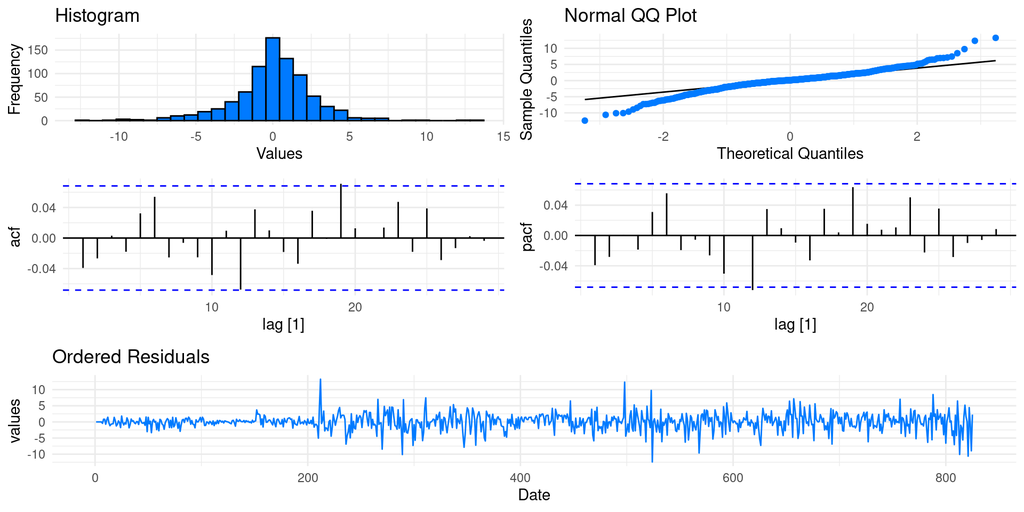

```r
# Store important information, like residuals, in a new data frame
arima_model_info <- augment(arima_models)

arima_model_info %>%
  filter(.model == "arima_111_011") %>%
  as.data.frame() %>%
  select(.resid) %>%
  unlist() %>%
  unname() %>%
  time_series$model_diagnostics()
```

The diagnostic plots above show that just about all the autocorrelation in the residuals has been removed, since the lines in both the ACF and PACF are now within the blue confidence limits. For the most part, our ordered residual plot shows no bad signs, since the series is quite stationary in the mean.

Our Box-Cox transformation may not have been enough to make the series have constant variance, since the variance up until the 200th observation is certainly different from what comes after. We’ll have to see later if this poses and issue.

One last thing to note is that the residual distribution and the Normal QQ Plot show that the residuals are close to but definitely not normally distributed. ARIMA models assume that the residuals follow a Gaussian white noise process. This assumption is important because when we forecast values, we like to generate prediction intervals to represent a margin for error.

Although the point forecasts will still be accurate, the intervals will not be if the residuals are not normally distributed. However, we can circumvent this issue by generating bootstrapped estimates for our intervals. So, having non-gaussian white noise residuals is completely fine in our case. As long as they are centered around zero and form a relatively symmetric distribution (they do), we’re looking good.

The other model we were interested in was ARIMA(0, 1, 2)(0, 1, 1). It’s diagnostic plots can be seen below, and they are almost identical to the previous ones.

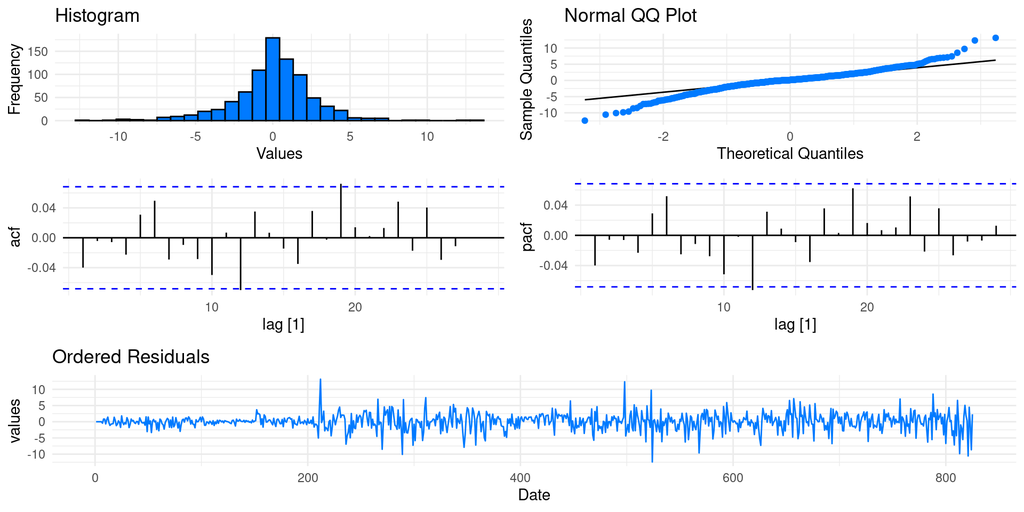

```r
arima_model_info %>%
  filter(.model == "arima_012_011") %>%
  as.data.frame() %>%
  select(.resid) %>%
  unlist() %>%
  unname() %>%
  time_series$model_diagnostics()
```

Since our residuals are consistently not normal, I figured it would be worth testing to see if a t-distribution better described them.

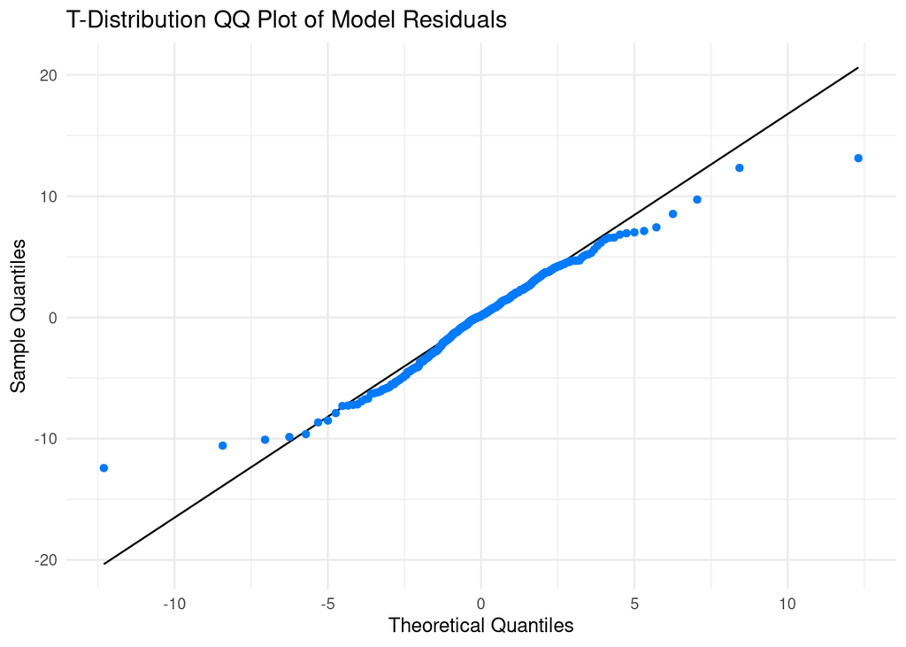

```r
# Store model residuals
arima_012_011_resid <- arima_model_info %>%
  filter(.model == "arima_012_011") %>%
  as.data.frame() %>%
  select(.resid) %>%
  unlist() %>%
  unname()

# Empirically estimate the residual t-distribution parameters
dist_params <- as.list(fitdistr(arima_012_011_resid, "t")$estimate)

# Generate plot
time_series$plotQQ(data_vec = arima_012_011_resid,
                   title = "T-Distribution QQ Plot of Model Residuals",
                   dist_func = stats::qt,
                   dparams = dist_params["df"])
```

This is certainly the case. Our t-distribution better accounts for the heavy tails that our residuals have. This confirms that our residuals are white noise, albeit not Gaussian white noise, which means we can simply bootstrap our prediction intervals to obtain accurate estimates.

### 4.4 Time Series Cross-Validation

As with most other prediction probelems in statistical modeling and machine learning, cross-validation is extremely important with time series forecasting. The goal of cross-validation is to help us choose a model that generalizes well to new data.

Time series cross-validation is very different from typical cross-validation though, since we can’t simply randomly sample the data for training and testing subsets. Time series data has a sequential structure, through time, and values depend on values that come immediately before it. So, we implement blocked-rolling window cross-validation.

The image below describes the idea succinctly.

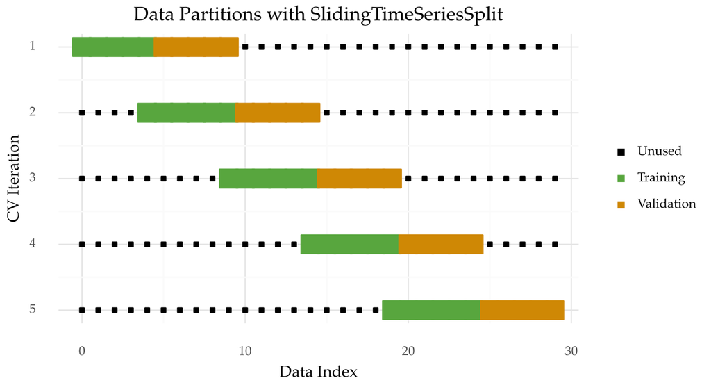

A subset of a reasonable size is chosen (in our case 100 observations) and is used to train the models, which then produce forecasts. The forecasts are compared to the actual values that the models have not seen, and error metrics are calculated, like Root Mean Squared Error (RMSE). Then the training subset **window** slides to use a new subset of training and testing data. The process is performed iteratively until we use all available subsets of data and the error metics for each model are aggregated. Then we can compare the results in a table.

However, also like most other models, time series cross-validation is very resource intensive and take a long time to complete. That is because we continuously fit hundreds or thousands of models on many subsets of the training data.

As a result, we can’t include the running code for it in our notebook, but I do provide a commented out codeblock that you can try running yourself with the data in the repository.

```r
# # Create blocked subsets of the data (training sets contains 100 observations each)
# cv_data <- post_covid_daily_ridership %>%
#   slide_tsibble(.size = 100, .step = 1) %>%
#   filter(!(.id %in% max(.id):(max(.id) - 13)))
#
# # Create a models using each of these training sets to obtain
# cv_arima_results <- cv_data %>%
#   model(
#     seasonal_diff = ARIMA(box_cox(avg_boardings, lambda) ~ pdq(0, 0, 0) + PDQ(0, 1, 0, period = 5)),
#     arima_000_011 = ARIMA(box_cox(avg_boardings, lambda) ~ pdq(0, 0, 0) + PDQ(0, 1, 1, period = 5)),
#     arima_100_011 = ARIMA(box_cox(avg_boardings, lambda) ~ pdq(1, 0, 0) + PDQ(0, 1, 1, period = 5)),
#     nonseasonal_diff = ARIMA(box_cox(avg_boardings, lambda) ~ pdq(0, 1, 0) + PDQ(0, 0, 0, period = 5)),
#     double_diff = ARIMA(box_cox(avg_boardings, lambda) ~ pdq(0, 1, 0) + PDQ(0, 1, 0, period = 5)),
#     arima_010_011 = ARIMA(box_cox(avg_boardings, lambda) ~ pdq(0, 1, 0) + PDQ(0, 1, 1, period = 5)),
#     arima_011_011 = ARIMA(box_cox(avg_boardings, lambda) ~ pdq(0, 1, 1) + PDQ(0, 1, 1, period = 5)),
#     arima_012_011 = ARIMA(box_cox(avg_boardings, lambda) ~ pdq(0, 1, 2) + PDQ(0, 1, 1, period = 5)),
#     arima_111_011 = ARIMA(box_cox(avg_boardings, lambda) ~ pdq(1, 1, 1) + PDQ(0, 1, 1, period = 5))
#     ) %>%
#   forecast(h = 14) %>%
#   accuracy(post_covid_daily_ridership) %>%
#   arrange(RMSE)
```

I’ve also included the results of the cross-validation in a table below.

```r
cv_arima_results <- data.frame(.model = c("arima_100_011", "arima_000_011", "arima_111_011", "arima_012_011", "arima_011_011", "seasonal_diff",
                                    "nonseasonal_diff", "arima_010_011", "double_diff"),
                         .type = rep("Test", times = 9),
                         ME = c(0.14783304, 0.02746709, -0.35253126, -0.34327737, -0.46380207, -0.68752152, -3.14639798, -3.44304494, -13.05370873),
                         RMSE = c(3.223771, 3.271745, 3.285186, 3.289071, 3.397887, 3.835413, 6.224038, 6.640184, 23.898601),
                         MAE = c(2.440754, 2.462462, 2.424498, 2.420800, 2.483459, 2.750422, 4.700696, 4.701008, 14.349139),
                         MPE = c(-3.768316, -5.124982, -7.476301, -7.394738, -8.278004, -11.180243, -34.198384, -34.438195, -119.482980),
                         MAPE = c(23.40163, 23.55276, 23.13448, 23.05037, 23.64924, 26.41330, 44.70273, 43.64248, 129.08697),
                         MASE = c(0.9332286, 0.9415288, 0.9270130, 0.9255990, 0.9495569, 1.0516310, 1.7973231, 1.7974425, 5.4864301),
                         RMSSE = c(0.8888389, 0.9020661, 0.9057719, 0.9068431, 0.9368454, 1.0574774, 1.7160548, 1.8307922, 6.5891805))

# Create a GT table
cv_arima_results %>%
  gt() %>%
  tab_style(
    style = list(
      cell_fill(color = "#2fa4e7")
    ),
    locations = list(cells_body(columns = RMSE, rows = RMSE == min(RMSE)),
                     cells_body(columns = MAE, rows = MAE == min(MAE)),
                     cells_body(columns = MPE, rows = abs(MPE) == min(abs(MPE))),
                     cells_body(columns = MAPE, rows = MAPE == min(MAPE)),
                     cells_body(columns = MASE, rows = MASE == min(MASE)),
                     cells_body(columns = RMSSE, rows = RMSSE == min(RMSSE))
    )
  ) %>%
  tab_footnote(footnote = "Highlighted cells are minimums for each column of interest. Smaller is better, except for MAE, (closest to zero).") %>%
  tab_header(title = "ARIMA Cross-Validation Error Metrics")
```

ARIMA Cross-Validation Error Metrics

| .model | .type | ME | RMSE | MAE | MPE | MAPE | MASE | RMSSE |
| --- | --- | --- | --- | --- | --- | --- | --- | --- |
| arima_100_011 | Test | 0.14783304 | 3.223771 | 2.440754 | -3.768316 | 23.40163 | 0.9332286 | 0.8888389 |
| arima_000_011 | Test | 0.02746709 | 3.271745 | 2.462462 | -5.124982 | 23.55276 | 0.9415288 | 0.9020661 |
| arima_111_011 | Test | -0.35253126 | 3.285186 | 2.424498 | -7.476301 | 23.13448 | 0.9270130 | 0.9057719 |
| arima_012_011 | Test | -0.34327737 | 3.289071 | 2.420800 | -7.394738 | 23.05037 | 0.9255990 | 0.9068431 |
| arima_011_011 | Test | -0.46380207 | 3.397887 | 2.483459 | -8.278004 | 23.64924 | 0.9495569 | 0.9368454 |
| seasonal_diff | Test | -0.68752152 | 3.835413 | 2.750422 | -11.180243 | 26.41330 | 1.0516310 | 1.0574774 |
| nonseasonal_diff | Test | -3.14639798 | 6.224038 | 4.700696 | -34.198384 | 44.70273 | 1.7973231 | 1.7160548 |
| arima_010_011 | Test | -3.44304494 | 6.640184 | 4.701008 | -34.438195 | 43.64248 | 1.7974425 | 1.8307922 |
| double_diff | Test | -13.05370873 | 23.898601 | 14.349139 | -119.482980 | 129.08697 | 5.4864301 | 6.5891805 |

Since we would like to minimize each of the error metrics, the cell containing the minimum for each column has been highlighted in blue. ARIMA(0, 1, 2)(0, 1, 1) has the most minimums across error metrics, tied with ARIMA(1, 0, 0)(0, 1, 1).

Therefore, we’ll choose ARIMA(0, 1, 2)(0, 1, 1) as our final model.

## 5 ETS Modeling

### 5.1 Discussion

ARIMA is a fantastic tool that is often perfectly suitable for modeling a great variety of time series data sets. However, it has a major limitation when it comes to modeling seasnality in data.

Although ARIMA can model some types of seasonality, it can only properly model short period seasonality. In other words, its great for explaining monthly seasonality, and weekly seasonality, but it struggles as the period length increases. So, if we wanted to model yearly seasonality with daily data, our model will not be able to handle such high peridocity, since we would have around 260 weekdays in a year (not 365, since we don’t look at weekends).

If we extend the initial ACF plot of our series, we can see that we in fact do have yearly seasonality.

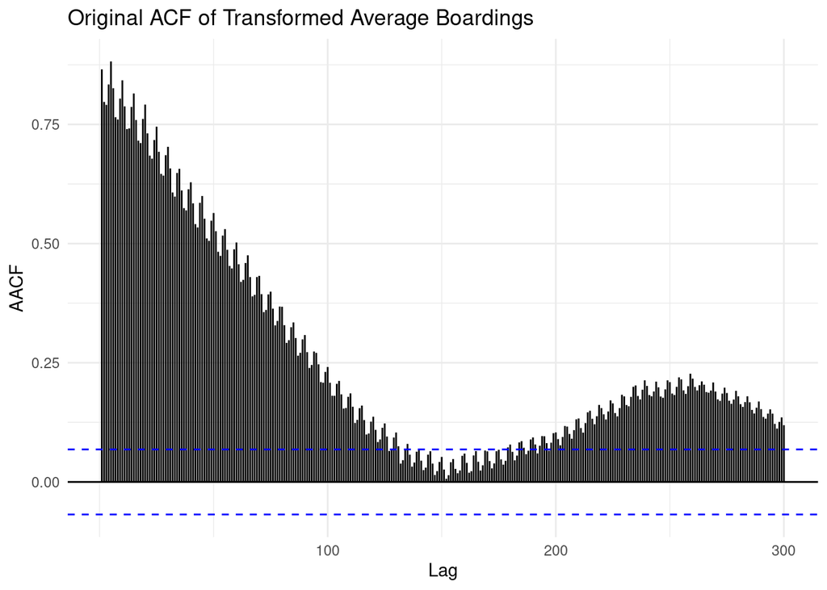

```r
post_covid_daily_ridership %>%
  ACF(avg_boardings_trans, lag_max = 300) %>%
  autoplot() +
  theme_minimal() +
  labs(x = "Lag",
       y = "AACF",
       title = "Original ACF of Transformed Average Boardings")
```

The autocorrelations decay initially, but then spike up yet again once a new year starts to enter the picture. They reach a peak at around lag 260 because that is when the first observationat time *t* is repeated at *t-260*.

This complex seasonality cannot be modeled by ARIMA, since it does not like high periodicity and it can only handle one type of seasonality at a time. We have already included weekly seasonality, so we need to explore different models.

### 5.2 Time Series Decomposition

Error-Trend-Seasonal models, better known as simply ETS, are a variety of exponential smoothing models that lay within the realm of state-space models in the literature. State-space models take advantage of Markov processes, which include a measurement function and a state function. The state function is recalculated as the time series progresses, reflecting a change of state in the data. You can read more about the details [here](https://otexts.com/fpp3/ets.html), and their applications to highly seasonal data [here](https://otexts.com/fpp3/complexseasonality.html).

ETS models can also be paired with Seasonal and Trend Decomposition using Loess (STL) methods. These help to decompose a time series into a trend component (up or down), one or more seasonal components, and a remainder component, which tends to be white noise when the previous components are filtered out.

They are very useful in modeling economic data, which researchers like to seasonally adjust to filter out cyclic activity and focus on only the trend.

Below is our Ferry Boardings data, decomposed into various parts.

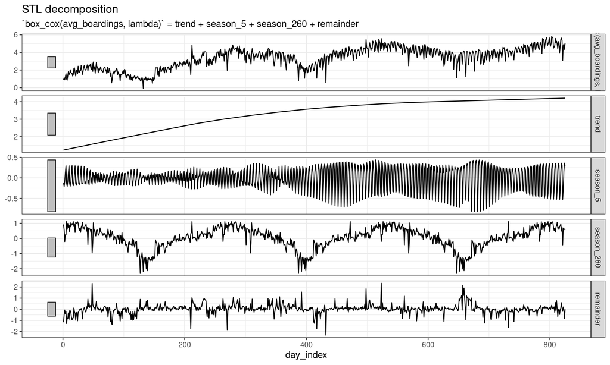

```r
post_covid_daily_ridership %>%
  model(
    STL(box_cox(avg_boardings, lambda) ~ season(5) + season(5*52),
        robust = TRUE)
  ) %>%
  components() %>%
  autoplot() +
  theme_bw()
```

Our top series is just the original average boardings series, with the Box-Cox transformation applied. The trend component is tending upward, as expected. However, now we can visualize the two seasonal components, separately.

The yearly seasonality is quite pronounced, which makes sense because time of year must have some impact on the ridership of the ferry. Colder days with snowier weather tend to encourage people to take other modes of transportation, or just telework. This trend is very consistent.

The weekly seasonality is certainly more complex. The cycles are very small and repeat with a greater frequency than the yearly seasonality does, so it can seem more **messy**. The variation is not consistent, which also makes the graph look strange at first. It’s clear that the recovery of ferry system, and the MBTA transit system as a whole, from Covid-19 is at work here. These transit systems were heavily disrupted by the pandemic and as a result the variance of the weekly seasonality is changing as the recovery effort progresses.

It’s also important to note the vertical bars beside each series. Wider bars indicate relatively narrower scales, whereas narrower bars indicate wider scales. So, we can compare both of our seasonal components and conclude that the yearly seasonality is strong and the weekly seasonality is relatively weak, although still present.

We can also visualize the trend overlayed on top of the original series.

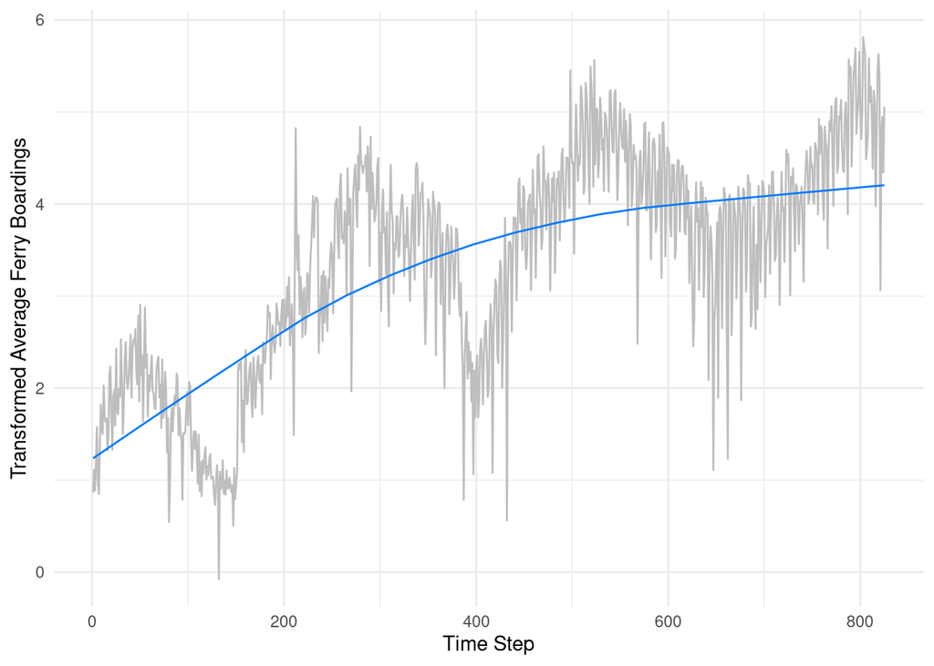

```r
components <- post_covid_daily_ridership %>%
  model(
    STL(box_cox(avg_boardings, lambda) ~ season(5) + season(5*52),
        robust = TRUE)
  ) %>%
  components()

# Trend graph
components %>%
  as_tsibble() %>%
  autoplot(`box_cox(avg_boardings, lambda)`, color = "gray") +
  geom_line(aes(y = trend), color = "#007aff") +
  theme_minimal() +
  labs(y = "Transformed Average Ferry Boardings",
       x = "Time Step")
```

This graph isn’t especially useful, even if it is nice to look at. However, it is reassuring since it conveys that, while a simple upward trend explains a lot about the series, the seasonality plays an important role as well (especially the yearly one).

### 5.3 ETS Fitting and Evaluation

ETS is great because there are automatic model fitting algorithms that do a very good job at specifying a model. This contrasts with ARIMA, where manual model selection, when performed correctly, is more time consuming and subjective.

We fit and cross validate using STL to decompose the series, and model the seasonal components using ETS, below.

```r
# Specify formula of model
my_dcmp_spec <- decomposition_model(
  STL(box_cox(avg_boardings, lambda) ~ season(5) + season(5*52),
      robust = TRUE),
  ETS(season_adjust ~ season("N"))
)
```

Again, cross-validation is resource intensive so I have commented out the lines of code below.

```r
# cv_ETS_results <- cv_data %>%
#   model(my_dcmp_spec) %>%
#   forecast(h = 14) %>%
#   accuracy(post_covid_daily_ridership)
```

I’ve placed the results that I obtained after cross-validating (using the same subsets as before) down below.

```r
cv_ETS_results <- data.frame(.model = c("my_dcmp_spec"),
                         .type = rep("Test", times = 1),
                         ME = c(-0.04352693),
                         RMSE = c(3.364336),
                         MAE = c(2.491663),
                         MPE = c(-6.2999),
                         MAPE = c(23.78435),
                         MASE = c(0.9526937),
                         RMSSE = c(0.9275948))
```

We can now compare the results for this model with our best ARIMA model.

```r
cv_ETS_results %>%
  rbind(cv_arima_results %>%
          filter(.model == "arima_012_011")) %>%
    gt() %>%
  tab_style(
    style = list(
      cell_fill(color = "#2fa4e7")
    ),
    locations = list(cells_body(columns = RMSE, rows = RMSE == min(RMSE)),
                     cells_body(columns = MAE, rows = MAE == min(MAE)),
                     cells_body(columns = MPE, rows = abs(MPE) == min(abs(MPE))),
                     cells_body(columns = MAPE, rows = MAPE == min(MAPE)),
                     cells_body(columns = MASE, rows = MASE == min(MASE)),
                     cells_body(columns = RMSSE, rows = RMSSE == min(RMSSE))
    )
  ) %>%
  tab_footnote(footnote = "Highlighted cells are minimums for each column of interest. Smaller is better, except for MAE, (closest to zero).") %>%
  tab_header(title = "ARIMA and ETS Cross-Validation Error Metrics")
```

ARIMA and ETS Cross-Validation Error Metrics

| .model | .type | ME | RMSE | MAE | MPE | MAPE | MASE | RMSSE |
| --- | --- | --- | --- | --- | --- | --- | --- | --- |
| my_dcmp_spec | Test | -0.04352693 | 3.364336 | 2.491663 | -6.299900 | 23.78435 | 0.9526937 | 0.9275948 |
| arima_012_011 | Test | -0.34327737 | 3.289071 | 2.420800 | -7.394738 | 23.05037 | 0.9255990 | 0.9068431 |

Highlighted cells are minimums for each column of interest. Smaller is better, except for MAE, (closest to zero).

At first glance it appears that ARIMA is still outperforming the STL/ETS model. However, this comparison is not exactly equal. One of the drawbacks of ETS and yearly seasonality is that the model needs to observe a full year of data to adequately understand the seasonal effects.

As a result, this comparison is not actually informative or valid.

We could recreate the many subsets of training data so that they each include a year’s worth of data (about 260 observations) and perform the cross-validation of the STL/ETS model on that. But, those results wouldn’t be comparable to the ARIMA cross-validation results either, since now the ARIMA models have less training data to work with.

I think it is best to simply test both models using last-block validation (simple train-test split). We’ll do this after we have finished creating our next model: Dynamic Harmonic Regression.

## 6 Dynamic Harmonic Regression Modeling

### 6.1 Discussion

Dynamic Harmonic Regression sounds fancy and complicated. It is actually not particularly complicated, even if it is fancy, since we are actually just using Fourier terms as regressors in a model regression equation.

Fourier terms are included because they do a remarkable job at modeling cyclicity with their sine and cosine functions. This makes it useful for modeling seasonality; in fact, they are capable of modeling any length of seasonality. The **dynamic** key word in the phrase *Dynamic Harmonic Regression* refers to the use of an ARIMA model to model the errors. This allows Fourier terms to handle seasonality and ARIMA to handle short term effects and upward/downward trends.

### 6.2 Model Fitting and Cross-Validation

Choosing these models also partly relies on the intuition learned from the time series decomposition we used earlier, although not directly. We learned from it that our weekly seasonality was somewhat weaker compared to the yearly seasonality we saw.

So, when we choose the number of Fourier terms to include for each seasonal component, we can base the choice on the relative strength of each seasonality.

Below, we specify the K in each Fourier component for number of candidate models. The choice of K should not exceed the seasonal period divided by 2. So, for our weekly seasonality, we’ll have to either specify 1 or 2, but no more. This is for computational reasons. We’ll keep this to 2 in all cases.

For yearly seasonality, our maximum number of terms is 260/2, or 130. 130 is far too many terms and will undoubtedly over smooth the results and produce poor forecasts. So, we’ll vary K at more reasonable values.

```r
# Create cross-validation subsets, each with a year's worth of training data.
cv_yearly_data <- post_covid_daily_ridership %>%
  slide_tsibble(.size = 260, .step = 1) %>%
  filter(!(.id %in% max(.id):(max(.id) - 13)))
```

```r
# Create cross-validated models and obtain results
# cv_dnr_results <- cv_yearly_data %>%
#   model(
#     dnr_5 = ARIMA(box_cox(avg_boardings, lambda) ~ PDQ(0, 0, 0) + pdq(d = 0) +
#                   fourier(period = 5, K = 2) + fourier(period = 5*52, K = 5)),
#     dnr_6 = ARIMA(box_cox(avg_boardings, lambda) ~ PDQ(0, 0, 0) + pdq(d = 0) +
#                   fourier(period = 5, K = 2) + fourier(period = 5*52, K = 6)),
#     dnr_7 = ARIMA(box_cox(avg_boardings, lambda) ~ PDQ(0, 0, 0) + pdq(d = 0) +
#                   fourier(period = 5, K = 2) + fourier(period = 5*52, K = 7)),
#     dnr_8 = ARIMA(box_cox(avg_boardings, lambda) ~ PDQ(0, 0, 0) + pdq(d = 0) +
#                     fourier(period = 5, K = 2) + fourier(period = 5*52, K = 8)),
#     dnr_9 = ARIMA(box_cox(avg_boardings, lambda) ~ PDQ(0, 0, 0) + pdq(d = 0) +
#                     fourier(period = 5, K = 2) + fourier(period = 5*52, K = 9)),
#     dnr_10 = ARIMA(box_cox(avg_boardings, lambda) ~ PDQ(0, 0, 0) + pdq(d = 0) +
#                     fourier(period = 5, K = 2) + fourier(period = 5*52, K = 10)),
#     dnr_11 = ARIMA(box_cox(avg_boardings, lambda) ~ PDQ(0, 0, 0) + pdq(d = 0) +
#                     fourier(period = 5, K = 2) + fourier(period = 5*52, K = 11)),
#     dnr_12 = ARIMA(box_cox(avg_boardings, lambda) ~ PDQ(0, 0, 0) + pdq(d = 0) +
#                     fourier(period = 5, K = 2) + fourier(period = 5*52, K = 12)),
#     dnr_13 = ARIMA(box_cox(avg_boardings, lambda) ~ PDQ(0, 0, 0) + pdq(d = 0) +
#                     fourier(period = 5, K = 2) + fourier(period = 5*52, K = 13)),
#     dnr_14 = ARIMA(box_cox(avg_boardings, lambda) ~ PDQ(0, 0, 0) + pdq(d = 0) +
#                     fourier(period = 5, K = 2) + fourier(period = 5*52, K = 14)),
#     dnr_15 = ARIMA(box_cox(avg_boardings, lambda) ~ PDQ(0, 0, 0) + pdq(d = 0) +
#                     fourier(period = 5, K = 2) + fourier(period = 5*52, K = 15))
#
#   ) %>%
#   forecast(h = 14) %>%
#   accuracy(post_covid_daily_ridership)
```

Again, we’ve commented out the cross-validation code. We’ll store the results in a data frame and compare each of the models.

```r
cv_dnr_results <- data.frame(.model = c("dnr_5", "dnr_6", "dnr_7", "dnr_8", "dnr_9" ,"dnr_10", "dnr_11", "dnr_12", "dnr_13", "dnr_14", "dnr_15"),
                             .type = rep("Test", times = 11),
                             ME = c(3.682696, 3.869685, 4.023506, 4.160865, 4.261606, 4.356978, 4.435123, 4.475619, 4.510217, 4.539399, 4.557391),
                             RMSE = c(5.355303, 5.548950, 5.713068, 5.864727, 5.964027, 6.064047, 6.142938, 6.193078, 6.223786, 6.260457, 6.282534),
                             MAE = c(4.358360, 4.526195, 4.660325, 4.778216, 4.866546, 4.959289, 5.025089, 5.049881, 5.080224, 5.113365, 5.125475),
                             MPE = c(22.73037, 24.24944, 25.43780, 26.52154, 27.31910, 28.02153, 28.66569, 28.97693, 29.31273, 29.51775, 29.65168),
                             MAPE = c(30.79498, 31.91541, 32.79894, 33.58833, 34.14775, 34.79158, 35.16298, 35.40930, 35.64543, 35.84333, 35.89459),
                             MASE = c(1.666430, 1.730602, 1.781887, 1.826963, 1.860736, 1.896197, 1.921356, 1.930835, 1.942436, 1.955108, 1.959739),
                             RMSSE = c(1.476532, 1.529924, 1.575173, 1.616988, 1.644366, 1.671943, 1.693694, 1.707519, 1.715985, 1.726096, 1.732183))

# Create the GT table
cv_dnr_results %>%
    gt() %>%
  tab_style(
    style = list(
      cell_fill(color = "#2fa4e7")
    ),
    locations = list(cells_body(columns = RMSE, rows = RMSE == min(RMSE)),
                     cells_body(columns = MAE, rows = MAE == min(MAE)),
                     cells_body(columns = MPE, rows = abs(MPE) == min(abs(MPE))),
                     cells_body(columns = MAPE, rows = MAPE == min(MAPE)),
                     cells_body(columns = MASE, rows = MASE == min(MASE)),
                     cells_body(columns = RMSSE, rows = RMSSE == min(RMSSE))
    )
  ) %>%
  tab_footnote(footnote = "Highlighted cells are minimums for each column of interest. Smaller is better, except for MAE, (closest to zero).") %>%
  tab_header(title = "Dynamic Harmonic Regression Cross-Validation Error Metrics")
```

Dynamic Harmonic Regression Cross-Validation Error Metrics

| .model | .type | ME | RMSE | MAE | MPE | MAPE | MASE | RMSSE |
| --- | --- | --- | --- | --- | --- | --- | --- | --- |
| dnr_5 | Test | 3.682696 | 5.355303 | 4.358360 | 22.73037 | 30.79498 | 1.666430 | 1.476532 |
| dnr_6 | Test | 3.869685 | 5.548950 | 4.526195 | 24.24944 | 31.91541 | 1.730602 | 1.529924 |
| dnr_7 | Test | 4.023506 | 5.713068 | 4.660325 | 25.43780 | 32.79894 | 1.781887 | 1.575173 |
| dnr_8 | Test | 4.160865 | 5.864727 | 4.778216 | 26.52154 | 33.58833 | 1.826963 | 1.616988 |
| dnr_9 | Test | 4.261606 | 5.964027 | 4.866546 | 27.31910 | 34.14775 | 1.860736 | 1.644366 |
| dnr_10 | Test | 4.356978 | 6.064047 | 4.959289 | 28.02153 | 34.79158 | 1.896197 | 1.671943 |
| dnr_11 | Test | 4.435123 | 6.142938 | 5.025089 | 28.66569 | 35.16298 | 1.921356 | 1.693694 |
| dnr_12 | Test | 4.475619 | 6.193078 | 5.049881 | 28.97693 | 35.40930 | 1.930835 | 1.707519 |
| dnr_13 | Test | 4.510217 | 6.223786 | 5.080224 | 29.31273 | 35.64543 | 1.942436 | 1.715985 |
| dnr_14 | Test | 4.539399 | 6.260457 | 5.113365 | 29.51775 | 35.84333 | 1.955108 | 1.726096 |
| dnr_15 | Test | 4.557391 | 6.282534 | 5.125475 | 29.65168 | 35.89459 | 1.959739 | 1.732183 |

Highlighted cells are minimums for each column of interest. Smaller is better, except for MAE, (closest to zero).

Judging by the table, we should use K=5 for our yearly seasonal specification. Therefore, we’ll have a total of 10 Fourier terms (5 sine and 5 cosine) for the yearly seasonal component.

## 7 Model Forecasting

We have spent our time so far determining what the optimal model specification is for each of the three types of models discussed: ARIMA, STL/ETS, and Dynamic Harmonic Regression. Now that we have determined what those are, we can begin generating forecasts for each of them.

But first, we need to create a final train-test split for our data. We’ll leave out 20 observations for the test set and keep 805 in the training set. In essence, we’ll be forecasting 4 weeks ahead (recall we only forecast weekday boardings).

```r
train_data <- post_covid_daily_ridership[1:(nrow(post_covid_daily_ridership) - 20), ]
test_data <- post_covid_daily_ridership[(nrow(post_covid_daily_ridership) - 19):nrow(post_covid_daily_ridership), ]
```

### 7.1 Generate Forecasts and Prediction Intervals

We’ll use the block of code below fit each model. The call to mutate that they are piped into contains an expression that essentially **adds** the models together.

```r
all_models <- train_data %>%
  model(
    ARIMA = ARIMA(box_cox(avg_boardings, lambda) ~ pdq(0, 1, 2) + PDQ(0, 1, 1, period = 5)),
    STL_ETS = my_dcmp_spec,
    DNR = ARIMA(box_cox(avg_boardings, lambda) ~ PDQ(0, 0, 0)  +
                  fourier(period = 5, K = 2) + fourier(period = 5*52, K = 5))
  ) %>%
  mutate(combination = (ARIMA + STL_ETS + DNR) / 3)
```

Technically, the models are not added. It is an expression that `fable` and `fabletools` understand and can use to generate forecasts. We’ll generate the forecasts now

```r
all_forecasts <- all_models %>%
  forecast(h = 20)
```

and then create the prediction intervals.

```r
all_intervals <- all_forecasts %>%
  hilo()
```

Below, we have created a new data frame that we can pass to a call to ggplot2 functions to generate a time series chart that compares each of the models’ forecasts to the actual test data.

```r
all_plot_data <- data.frame(.model = all_intervals$.model,
                            date = test_data$new_date,
                            actual = test_data$avg_boardings,
                            point_forecast = all_intervals$.mean,
                            low_80 = all_intervals$`80%`$lower,
                            high_80 = all_intervals$`80%`$upper,
                            low_95 = all_intervals$`95%`$lower,
                            high_95 = all_intervals$`95%`$upper)
```

First, we’ll create the graph for the Dynamic Harmonic Regression. The code for this, like the others that will follow, will initially be hidden since they take up so much space. If you’re curious, you can show the code by clicking the show button to the right of each.

```r
dnr_plot <- ggplot() +
    geom_line(data = train_data[(nrow(train_data) - 40):nrow(train_data),],
              mapping = aes(x = new_date, y = avg_boardings),
              color = "#007aff") +
    geom_ribbon(data = all_plot_data %>% filter(.model == "DNR"),
                mapping = aes(ymin = low_95, ymax = high_95, x = date),
                fill = "#ffe4bf") +
    geom_ribbon(data = all_plot_data %>% filter(.model == "DNR"),
                mapping = aes(ymin = low_80, ymax = high_80, x = date),
                fill = "#ffaf3f") +
    geom_line(data = all_plot_data %>% filter(.model == "DNR"),
              mapping = aes(x = date, y = point_forecast),
              color = "#ED8B00") +
    geom_line(data = all_plot_data %>% filter(.model == "DNR"),
              mapping = aes(x = date, y = actual),
              color = "#007aff") +
    theme_minimal() +
    labs(y = "Average Boardings",
         x = "",
         title = "Dynamic Harmonic Regression")
```

Next the graph for the STL/ETS model.

```r
ETS_plot <- ggplot() +
    geom_line(data = train_data[(nrow(train_data) - 40):nrow(train_data),],
              mapping = aes(x = new_date, y = avg_boardings),
              color = "#007aff") +
    geom_ribbon(data = all_plot_data %>% filter(.model == "STL_ETS"),
                mapping = aes(ymin = low_95, ymax = high_95, x = date),
                fill = "#f9d4d1") +
    geom_ribbon(data = all_plot_data %>% filter(.model == "STL_ETS"),
                mapping = aes(ymin = low_80, ymax = high_80, x = date),
                fill = "#ed7f77") +
    geom_line(data = all_plot_data %>% filter(.model == "STL_ETS"),
              mapping = aes(x = date, y = point_forecast),
              color = "#DA291C") +
    geom_line(data = all_plot_data %>% filter(.model == "STL_ETS"),
              mapping = aes(x = date, y = actual),
              color = "#007aff") +
    theme_minimal() +
    labs(x = "",
         y = "",
         title = "STL/ETS")
```

The ARIMA model.

```r
ARIMA_plot <- ggplot() +
    geom_line(data = train_data[(nrow(train_data) - 40):nrow(train_data),],
              mapping = aes(x = new_date, y = avg_boardings),
              color = "#007aff") +
    geom_ribbon(data = all_plot_data %>% filter(.model == "ARIMA"),
                mapping = aes(ymin = low_95, ymax = high_95, x = date),
                fill = "#feccfe") +
    geom_ribbon(data = all_plot_data %>% filter(.model == "ARIMA"),
                mapping = aes(ymin = low_80, ymax = high_80, x = date),
                fill = "#ff66ff") +
    geom_line(data = all_plot_data %>% filter(.model == "ARIMA"),
              mapping = aes(x = date, y = point_forecast),
              color = "#660066") +
    geom_line(data = all_plot_data %>% filter(.model == "ARIMA"),
              mapping = aes(x = date, y = actual),
              color = "#007aff") +
    theme_minimal() +
    labs(x = "Date",
         y = "Average Boardings",
         title = "ARIMA")
```

And finally the combination forecast.

```r
combination_plot <- ggplot() +
    geom_line(data = train_data[(nrow(train_data) - 40):nrow(train_data),],
              mapping = aes(x = new_date, y = avg_boardings),
              color = "#007aff") +
    geom_line(data = all_plot_data %>% filter(.model == "combination"),
              mapping = aes(x = date, y = point_forecast),
              color = "#1a7e2e") +
    geom_line(data = all_plot_data %>% filter(.model == "combination"),
              mapping = aes(x = date, y = actual),
              color = "#007aff") +
    theme_minimal() +
    labs(x = "Date",
         y = "",
         title = "Combination Forecast")
```

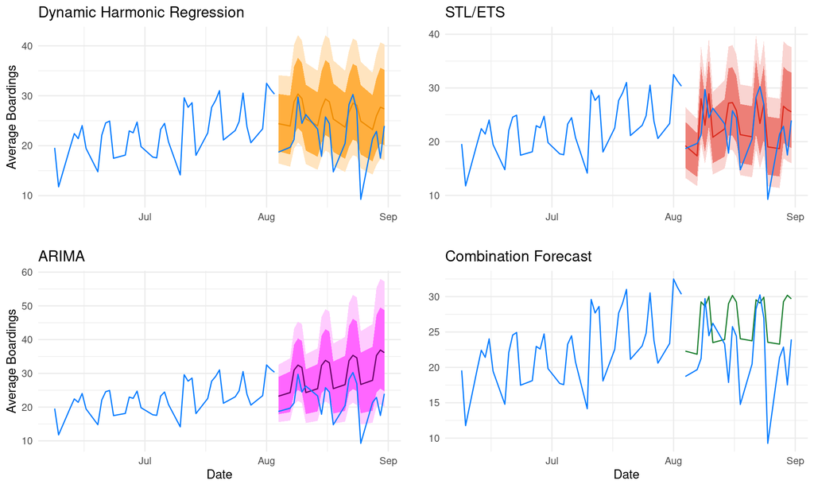

```r
grid.arrange(
  dnr_plot,
  ETS_plot,
  ARIMA_plot,
  combination_plot,
  ncol = 2
)
```

### 7.2 Some Discussion

There is a lot to unpack regarding the plot above. First, you’ll notice that the combination forecast is not accompanied by a prediction interval, while the others are. This is because, while we can easily generate combination point forecasts by simply averaging the point forecasts of the other models. However, generating the distribution for the combination forecast is much more complex.

We can do this, but we haven’t yet in order to highlight another interesting point. The ARIMA model’s forecasts are atrocious. The model assumes that the upward trend present in the series will continue in the test data. But the test data is beginning to slowly trend downwards due to the yearly seasonality patterns that the ARIMA model does NOT take into account.

The test data points all are from the month of August, which is typically when weather starts to get colder in Boston and the surrounding area. So, the apex of the yearly seasonal pattern typically occurs around August, maybe September. That is also when ridership decreases.

Since ARIMA cannot model multiple seasonal trends, it should be concluded that it is not suitable and we should also create a combination forecast that only average the forecasts of the other two models.

Which brings us to the next point of discussion. The Dynamic Harmonic Regression and the ETS model both perform quite well. Most of the test data falls within the prediction intervals. The only test data point that is well outside of both is the date Auguest 25th, 2023. This Friday has an unusually low value, even wen considering the shift to a downward trend.

Its value is about 9.26 average weekday boardings. I could find no reason why the number of boardings was so low, so we have to conclude that it is simply an unusual data point, an outlier.

Lastly, notice how the DNR model looks like it is noticing the upcoming downward trend. This is because the underlying model uses the Fourier terms to model the seasonality, and it actually assumes that this seasonality remains constant. The ETS model also tends to recognize the change in trend, but not quite as well.

As it turns out, the ETS model outperforms the others by a large margin. It wins in all the relevant error metrics.

The quantitative results of the forecasting are in the table below.

```r
all_forecasts %>%
  accuracy(post_covid_daily_ridership) %>%
  as.data.frame() %>%
  select(-c(ACF1)) %>%
  gt() %>%
  tab_style(
    style = list(
      cell_fill(color = "#2fa4e7")
    ),
    locations = list(cells_body(columns = RMSE, rows = RMSE == min(RMSE)),
                     cells_body(columns = MAE, rows = MAE == min(MAE)),
                     cells_body(columns = MPE, rows = abs(MPE) == min(abs(MPE))),
                     cells_body(columns = MAPE, rows = MAPE == min(MAPE)),
                     cells_body(columns = MASE, rows = MASE == min(MASE)),
                     cells_body(columns = RMSSE, rows = RMSSE == min(RMSSE))
    )
  ) %>%
  tab_footnote(footnote = "Highlighted cells are minimums for each column of interest. Smaller is better, except for MAE, (closest to zero).") %>%
  tab_header(title = "Out-of-Sample Forecast Accuracy")
```

Out-of-Sample Forecast Accuracy

| .model | .type | ME | RMSE | MAE | MPE | MAPE | MASE | RMSSE |
| --- | --- | --- | --- | --- | --- | --- | --- | --- |
| ARIMA | Test | -8.172665 | 9.613989 | 8.364725 | -44.20972 | 44.94193 | 3.219610 | 2.671260 |
| DNR | Test | -4.321778 | 6.170359 | 4.734436 | -26.97686 | 28.42061 | 1.822300 | 1.714443 |
| STL_ETS | Test | -1.481156 | 5.079817 | 3.974327 | -12.27347 | 21.70458 | 1.529731 | 1.411434 |
| combination | Test | -4.658533 | 6.477757 | 5.156566 | -27.82002 | 29.61111 | 1.984779 | 1.799854 |

Highlighted cells are minimums for each column of interest. Smaller is better, except for MAE, (closest to zero).

### 7.3 Revisiting Combination Forecasts

Since we have determined that ARIMA actually hinders the combination forecasts, we should remove it and recalculate the combination.

```r
relevant_models <- train_data %>%
  model(
    STL_ETS = my_dcmp_spec,
    DNR = ARIMA(box_cox(avg_boardings, lambda) ~ PDQ(0, 0, 0)  +
                  fourier(period = 5, K = 2) + fourier(period = 5*52, K = 5))
  ) %>%
  mutate(combination = (STL_ETS + DNR) / 2)
```

Next we’ll produce the forecasts and generate the combined error distribution.

```r
final_forecasts <- relevant_models %>%
  generate(h = 20, times = 1000) %>%
  as_tsibble() %>%
  group_by(.model) %>%
  summarize(
    dist = distributional::dist_sample(list(.sim))
  ) %>%
  ungroup() %>%
  as_fable(index = day_index, key = .model,
           distribution = dist, response = "avg_boardings") %>%
  filter(.model == "combination")
```

```r
final_forecast_intervals <- final_forecasts %>%
  filter(.model == "combination") %>%
  hilo()
```

Create the plotting data frame.

```r
final_forecast_plot_data <- data.frame(.model = final_forecast_intervals$.model,
                                       date = test_data$new_date,
                                       actual = test_data$avg_boardings,
                                       point_forecast = final_forecast_intervals$dist %>% mean(),
                                       low_80 = final_forecast_intervals$`80%`$lower,
                                       high_80 = final_forecast_intervals$`80%`$upper,
                                       low_95 = final_forecast_intervals$`95%`$lower,
                                       high_95 = final_forecast_intervals$`95%`$upper)
```

And lastly we’ll plot the data.

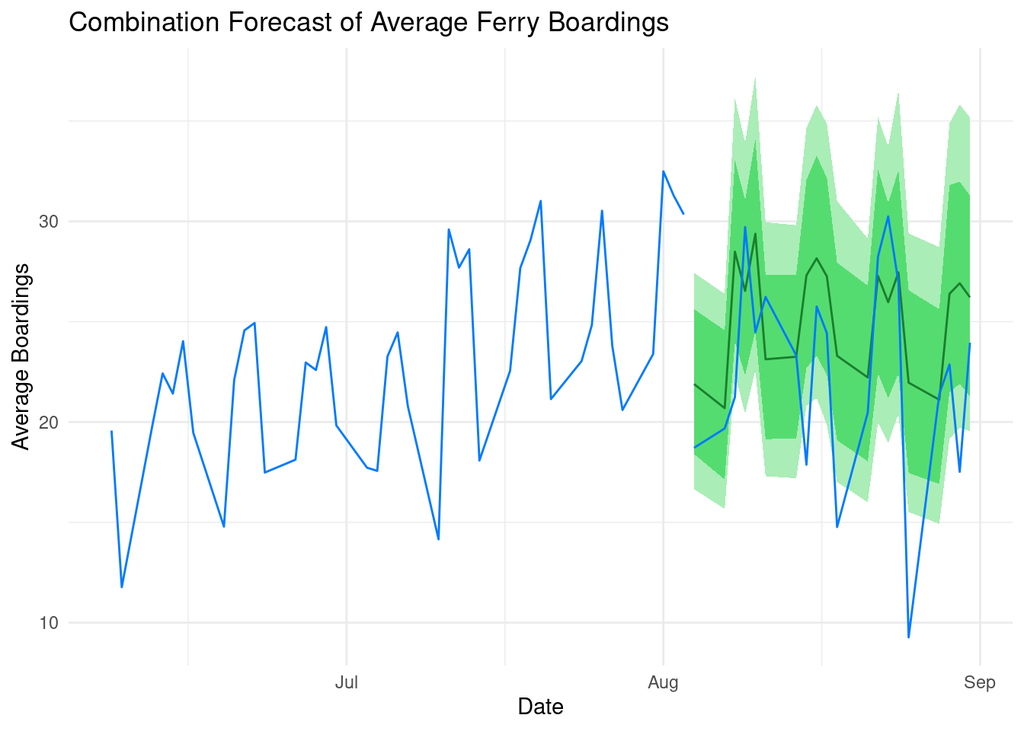

```r
ggplot() +
    geom_line(data = train_data[(nrow(train_data) - 40):nrow(train_data),],
              mapping = aes(x = new_date, y = avg_boardings),
              color = "#007aff") +
    geom_ribbon(data = final_forecast_plot_data,
                mapping = aes(ymin = low_95, ymax = high_95, x = date),
                fill = "#aaedb7") +
    geom_ribbon(data = final_forecast_plot_data,
                mapping = aes(ymin = low_80, ymax = high_80, x = date),
                fill = "#55dc70") +
    geom_line(data = final_forecast_plot_data,
              mapping = aes(x = date, y = point_forecast),
              color = "#1a7e2e") +
    geom_line(data = final_forecast_plot_data,
              mapping = aes(x = date, y = actual),
              color = "#007aff") +
    theme_minimal() +
    labs(x = "Date",
         y = "Average Boardings",
         title = "Combination Forecast of Average Ferry Boardings")
```

The forecasts look quite similar to the DNR model, with some slight differences due to the combination with the ETS forecasts.

We’ll make another table comparing these forecasts with the DNR and the ETS models.

```r
final_forecasts %>%
  accuracy(post_covid_daily_ridership) %>%
  as.data.frame() %>%
  select(-c(ACF1)) %>%
  rbind(all_forecasts %>%
          accuracy(post_covid_daily_ridership) %>%
          as.data.frame() %>%
          select(-c(ACF1)) %>%
          filter(.model %in% c("DNR", "STL_ETS"))) %>%
  gt() %>%
  tab_style(
    style = list(
      cell_fill(color = "#2fa4e7")
    ),
    locations = list(cells_body(columns = RMSE, rows = RMSE == min(RMSE)),
                     cells_body(columns = MAE, rows = MAE == min(MAE)),
                     cells_body(columns = MPE, rows = abs(MPE) == min(abs(MPE))),
                     cells_body(columns = MAPE, rows = MAPE == min(MAPE)),
                     cells_body(columns = MASE, rows = MASE == min(MASE)),
                     cells_body(columns = RMSSE, rows = RMSSE == min(RMSSE))
    )
  ) %>%
  tab_footnote(footnote = "Highlighted cells are minimums for each column of interest. Smaller is better, except for MAE, (closest to zero).") %>%
  tab_header(title = "Out-of-Sample Forecast Accuracy")
```

Out-of-Sample Forecast Accuracy

| .model | .type | ME | RMSE | MAE | MPE | MAPE | MASE | RMSSE |
| --- | --- | --- | --- | --- | --- | --- | --- | --- |
| combination | Test | -2.890371 | 5.350911 | 4.076847 | -19.60092 | 23.76679 | 1.569192 | 1.486758 |
| DNR | Test | -4.321778 | 6.170359 | 4.734436 | -26.97686 | 28.42061 | 1.822300 | 1.714443 |
| STL_ETS | Test | -1.481156 | 5.079817 | 3.974327 | -12.27347 | 21.70458 | 1.529731 | 1.411434 |

Highlighted cells are minimums for each column of interest. Smaller is better, except for MAE, (closest to zero).

### 7.4 Final Discussion on Results

We can see that, despite removing ARIMA from the combination forecast equation, the combinations are inadequate compared to the STL/ETS forecasts. In many cases combination forecasts improve performance, but not in all cases.

I believe that this result stems from the fact that ARIMA cannot adequately model all types of seasonality and can’t even model multiple seasonality. Dynamic Harmonic Regression, while still a decent choice, performs worse than ETS. The reason for this may be that DNR tends to overfit models, since it uses a large number of parameters.

In our case, the DNR model had 4 parameters for weekly seasonality, 10 for yearly seasonality, and 6 combined moving average and autoregressive parameters for modeling the errors. 20 parameters is a lot compared to the ETS model, which was essentially a seasonal random walk model (for both seasonalities) with a simple exponential smoother with additive errors (ETS[A, N, N]). In other words, we only estimated a single parameter for the exponential smoother applied to the seasonally adjusted component of the series (alpha).

Many analysts, statisticians, and data scientists will parrot the old saying of simplicity is often better. They are usually right, and it turns out that is correct in our case as well.

## 8 Improvements

To finish off the work we have done here, I would like to suggest some improvements to the work.

1. We aggregated the data according to day. We obtained astonishingly good forecasts, despite one observation (an outlier) existing outside of the prediction intervals for the STL/ETS model.
   - Perhaps foregoing the aggregation by day and instead aggregating by hour would be more appropriate.
   - It’s certainly reasonable to assume that a daily seasonality exists over the course of 24 hours (or however many hours the ferries are operational).
2. Apply vector autoregression, or add exogenous predictor variables, including variables that measure impactful weather.
   - We’ve seen data points representing canceled days due to weather. Maybe including variables for rainfall and snowfall could influence decreases in ridership even when services are not cancelled.

These are the two most interesting and obvious routes to explore. There could be additional variables that I have not thought of that could also be included as predictors for average ridership.

If you have any ideas on how to improve this work, please do not hesitate to reach out and make suggestions. This is a very interesting problem involving a highly complex, seasonal set of data, and I think time series analysis has a real application here.

*Thank you for reading!!!*